# Tutorial on niche-neutral GLMMs to understand community assembly

Sara Mortara et al.

30 maio, 2019

### The framework

The general idea of our framework is to translate niche and neutral dynamics on community assembly into fixed and random effects of generalized mixed models. Within our framework one can simultaneously test the importance of niche solely, neutrality solely and combinations of niche and neutral effects on community structure (abundance or occurrence).

We use the model selection approach to test multiple hypothesis and we use conditional and marginal $R^{2}$ values to quantify the relative importance of niche and neutrality on community structure.

Main criticism of our framework rely on: (1) Are fixed and random effects actually capturing niche and neutral dynamics? (2) Are random effects only capturing neutral dynamics or uninformed species traits are inflating random effects?

In order to show how we implemented our framework and how model components are translated into niche and neutral dynamics we performed simulations as described below. We do not intend to scan all parameter space of type of communities and traits, neither make a comprehensive investigation of sampling effects. Our goal with this tutorial is to address main criticisms of our framework and show how promising our framework is to quantify the relative importance of niche and neutral dynamics.

## A test of our modelling framework

Here, we present a working example of our modelling framework. We use simulated communities based on niche and neutral dynamics in order to show how fixed and random effects capture different ecological processes. Also, we use traits with strong and weak correlations to species abundance in order to show how fixed and random effects capture neutral dynamics when traits are uninformative. Therefore, we simulate stochastic and deterministic meta-communities and use strong or weak traits in model selection.

We simulate meta-communities with the same data structure as our abundance data of ferns in three mountain chains in southern Brazil. Then, we make Poisson of communities and use samples from the meta-communities in our model selection framework.

In order to address main criticisms of our framework, we analyze into three scenarios:

- Deterministic community with traits strongly correlated with species abundance from Poisson sample
- Deterministic community with traits poorly correlated with species abundance from Poisson sample
- Stochastic community with traits strongly correlated with species abundance from Poisson sample

### 1. Building simulated communities

#### 1.1. Getting data for simulations

The simulations are based on several packages that should be installed in the user’s computer before starting the tutorial. The packages bellow should be installed as regular CRAN packages before loaded. To check if they are already installed run the code below.

```r
packages <- c("devtools", "ade4", "vegan", "lme4", "bbmle", "optimx",
              "piecewiseSEM", "sads", "ggplot2", "dplyr", "MASS", "knitr")
instpack <- packages[!packages %in% installed.packages()]
if(length(instpack)>0)
{
    install.packages(packages[!packages %in% installed.packages()])
}
```

One of the packages needed in this tutorial, MCSim (MetaCommunity Simulation) is not available at CRAN and should be installed directly from the development repository github. Follow the code bellow to install it. Information about this package can be found at [MCSim](http://rstudio-pubs-static.s3.amazonaws.com/159425_80725873417e42fdb13821c10a198281.html)

```r
if(! "MCSim" %in% installed.packages())
{
    devtools::install_github("sokole/MCSim")
}
```

Attach all packages needed to running this tutorial.

```r
library(devtools)
library(MCSim)
library(ade4)
library(vegan)
library(lme4)
library(bbmle)
library(optimx)
library(piecewiseSEM)
library(sads)
library(ggplot2)
library(dplyr)
library(MASS)
library(knitr)
source("../code/functions.R")
```

Here we specify the random number generator seed:

```r
set.seed(42)
```

For both deterministic and stochastic scenarios, we simulate 10 different meta-communities until time-step 100 and then take the mean of the abundances at the 100<sup>ht</sup> last time-step of each simulation.

```r
## Number of sites
Nsites <- 30
## Number of regions
Nregions <- 3
## Number of species
Nspp <- 153

## Sites attributes ##
## Here are the xy-coordinates of sites: 3 regions with 10 sites each
## Distances between regions is an order of magnitude distance bewteen sites within regions
sites <- expand.grid(x = seq(0,120, length=Nregions), y=seq(1,5, length=Nsites/Nregions))
sites$x <- jitter(sites$x)
sites$y <- jitter(sites$y)
## Each set of 10 points at same x coordinate is labelled as a region
sites$region <- rep(letters[1:Nregions], Nsites/Nregions)
## Enviromental variable: 10 states, that repeat at each site (e.g. altitude)
sites$env <- rep(seq(1,5, length=Nsites/Nregions), each=Nregions)

## Calculate niches for species: optimal values along the enviromental variable
sp.opt <- runif(Nspp, min = 1, max = 5)
```

Here, we generate the sites x species matrix with community initial conditions to run the simulations.

```r
## Initial condition ##
## Initial condition: matrix of sites x spp

## Random values of species abundances
m0b <- matrix(rlnorm(Nspp*Nsites), Nsites, Nspp)
## Round values of species abundance to represent discrete values of number of individuals
m0b <- round(m0b)
## Splitting species in 3 fractions that are exclusive of each region
R.ind <- sample(letters[1:Nregions], Nspp, replace=TRUE)
for(i in letters[1:Nregions])
  m0b[sites$region==i,R.ind!=i] <- 0
## Calculating Relative abundances
m0b <- sweep(m0b, 1, apply(m0b,1,sum), FUN="/")
```

#### 1.2 Deterministic community

##### 1.2.1 Building the landscape

```r
## Following Sokol's tutorial we arbitrarily chose JM = 1e6
JM <- 1e6

## We set m=0.5 to allow some dispersal limitation. Still a half of the deaths are replaced by locals
simulation_landscape_det <- MCSim::fn.make.landscape(
  site.coords = sites[,1:2],
  Ef = sites$env,
  m = 0.5,
  JM = JM)
## It seems that in R 3.5 it is necessary to convert the dist mat in this object form dataframe to a matrix
simulation_landscape_det$dist.mat <-  as.matrix(simulation_landscape_det$dist.mat)
```

##### 1.2.2 Simulating abundances of deterministic communities

```r
## Data frames to store simulations
id <- data.frame(site=rep(1:Nsites, Nspp), sites[,3:4], spp=rep(paste("sp",1:Nspp, sep="."), each=Nsites))
## To store simulation results
Nrep <- 10
det.resu <- matrix(NA, nrow=nrow(id), ncol=Nrep)

for(i in 1:Nrep){
    simu.det <- MCSim::fn.metaSIM( # simulation of deterministic community w correctly observed traits
                           landscape = simulation_landscape_det,
                           ##output.dir.path = 'FERN_SIM_RESULTS_det',
                           ##scenario.ID = 'fern_det',
                           ##sim.ID = 'det',
                           trait.Ef = sp.opt,
                           trait.Ef.sd = 0.5,
                           J.t0 = m0b,
                           ##gamma.abund = gama.init/(sum(gama.init)),
                           n.timestep = 100, # increased to 100 time steps; initial conditions seems to persist after t=30
                           W.r = 0,
                           nu = 0,
                           speciation.limit = 0,
                           save.sim = FALSE
                       )
    det <- subset(simu.det$J.long, timestep=="100")[,4]
    det.resu[,i] <- det
}

det <- data.frame(id, count=rowMeans(det.resu))
```

#### 1.3 Stochastic community

##### 1.3.1 Simulating the landscape

```r
simulation_landscape_sto <- MCSim::fn.make.landscape(
  site.coords = sites[,1:2],
  Ef = sites$env,
  m = 0.5,
  JM = JM)
## It seems that in R 3.5 it is necessary to convert
## the dist mat in this object from dataframe to a matrix
simulation_landscape_sto$dist.mat <-  as.matrix(simulation_landscape_sto$dist.mat)
```

##### 1.3.2 Simulating abundances of stochastic communities

```r
## A matrix for the results
sto.resu <- matrix(NA, nrow=nrow(id), ncol=Nrep)

for(i in 1:Nrep){
    simu.sto <- MCSim::fn.metaSIM(
                           landscape = simulation_landscape_sto,
                           #output.dir.path = 'FERN_SIM_RESULTS_sto_RT',
                           #scenario.ID = 'fern__sto_RT',
                           #sim.ID = 'sto_RT',
                           trait.Ef = sp.opt,
                           trait.Ef.sd = 1000, # niche deviation changed for neutral dynamics
                           J.t0 = m0b,
                           ##gamma.abund = gama.init/(sum(gama.init)),
                           n.timestep = 100,
                           W.r = 200, # Dispersal Kernel no longer flat
                           nu = 0,
                           speciation.limit = 0,
                           save.sim = FALSE
                       )
    sto <- subset(simu.sto$J.long, timestep=="100")[,4]
    sto.resu[,i] <- sto
}

sto <- data.frame(id, count=rowMeans(sto.resu))
```

#### 1.4 Taking samples from simulated communities

Then, we take Poisson samples of the different scenarios.

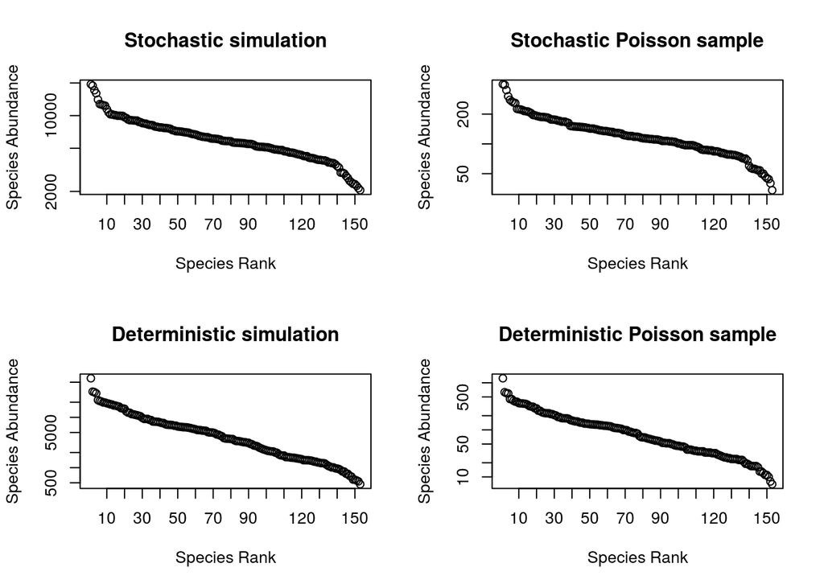

```r
Nsamp <- 0.02
# Poisson samples
## Deterministic community
det.pois <- rpois(length(det$count), det$count*Nsamp)
## Stochastic community
sto.pois <- rpois(length(sto$count), sto$count*Nsamp)

## Looking into results from simulation and sample
par(mfrow=c(2,2))
xtabs(sto$count~sto$spp)%>% as.vector() %>% rad() %>% plot(main="Stochastic simulation")
xtabs(sto.pois~sto$spp)%>% as.vector() %>% rad() %>% plot(main="Stochastic Poisson sample")
xtabs(det$count~det$spp)%>% as.vector() %>% rad() %>% plot(main="Deterministic simulation")
xtabs(det.pois~det$spp)%>% as.vector() %>% rad() %>% plot(rad(det.pois), main="Deterministic Poisson sample")
```

```r
par(mfrow=c(1,1))
```

### 2. Building hypothesis and models

We aim to simultaneously test these four main hypotheses:

1. Neutral and niche dynamics affect species abundance
2. Solely neutral dynamics affect species abundance
3. Solely niche dynamics affect species abundance
4. Species abundances vary randomly across regions (null model)

In order to represent each hypothesis, we will build a set of models using GLMM with fixed and random effects as below. Niche dynamics are represented by trait and environment effects, whereas neutral dynamics are represented by species, sites and region effects as random effects. Given that species traits are measured at species level, we included species as a random effect on all models (explicitly or implicity fo models with the term 1+grad|spp). Therefore, this random effect does not represent neutral or dynamics, but an indiosyncratic effect of species allowing a random intercept for species abundances.

| Hypothesis | Fixed Effects | Random Effects |
| --- | --- | --- |
| Neutral and niche dynamics | trait * (grad + I(grad^2)) | (1\|spp) + (1+grad\|site) + (1\|spp:site) + (1\|spp:region) |
|  | grad + I(grad^2) | (1+grad\|spp) + (1+grad\|site) + (1\|spp:site) + (1\|spp:region) |
| Solely neutral dynamics | - | (1\|site) + (1\|spp:site) + (1\|spp:region) |
| Solely niche dynamics | trait * (grad + I(grad^2)) | (1\|spp) + (1+grad\|site) |
|  | grad + I(grad^2) | (1+grad\|spp) + (1+grad\|site) |
| Null model | - | (1\|spp) + (1\|site) + (1\|region) |

### 3. Buildind the models

#### 3.1. Preparing data table for the models

##### Preparing abundance, trait and environmental data

Here, we combine species abundance data sampled from deterministic and stochastic simulations with traits and environmental data.

```r
# Binding all data togheter
data <- data.frame(site=id[,"site"], spp=id[,"spp"],
                   det=det.pois, sto=sto.pois)

# Now we need species traits, gradient and spacial info

## Traits
## A vector with wrong traits with correlation of less than 0.01 with the true traits
cor.t <- 1
while(cor.t>0.01){
    wrong.t <- runif(length(sp.opt), min(sp.opt), max(sp.opt))
    cor.t <- abs(cor(wrong.t, sp.opt))
}
## Trait data
trait.data <- data.frame(spp=unique(id$spp), trait= scale(sp.opt),
                    trait.wr=scale(wrong.t)) # creating vector w/ wrong traits
## Gradient
env.data <- data.frame(site=unique(id$site), grad=scale(sites$env),
                       region=sites$region)

## Preparing data table for model selection
all.data <- merge(data, env.data, by=c("site"))
all.data <- merge(all.data, trait.data, by=c("spp"))
```

A quick check show that all species were included in the sample

```r
samp.tot <- all.data %>%
    group_by(spp) %>%
    summarise(det.tot=sum(det), sto.tot= sum(sto))
any(samp.tot$det.tot<=0)
```

```
## [1] FALSE
```

```r
any(samp.tot$sto.tot<=0)
```

```
## [1] FALSE
```

Abundances curves of species across the environmental gradient are as expected:

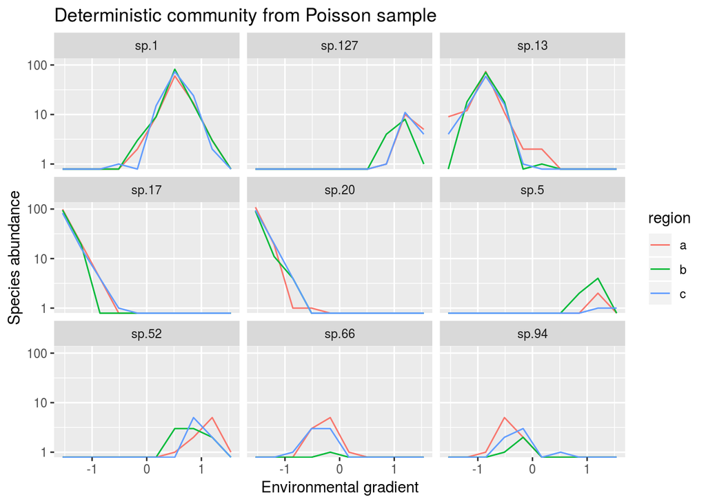

```r
## A sample of 9 species, a panel for each region
index <- paste("sp",sample(1:nlevels(all.data$spp),9),sep=".")
## Niche
all.data %>%
    filter(spp%in%index) %>%
    ggplot(aes(grad, det)) + geom_line(aes(colour=region)) + facet_wrap(~spp) +
    scale_y_log10() +
    labs(x="Environmental gradient", y="Species abundance",
         title=paste("Deterministic community from Poisson sample"))
```

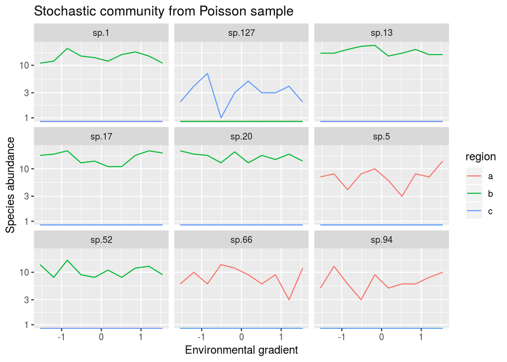

```r
## Neutral
all.data %>%
    filter(spp%in%index) %>%
    ggplot(aes(grad, sto)) + geom_line(aes(colour=region)) + facet_wrap(~spp) +
    scale_y_log10() +
    labs(x="Environmental gradient", y="Species abundance",
         title=paste("Stochastic community from Poisson sample"))
```

#### 3.2 Adjusting model to the data

First, we create simple functions to perform model selection. Although the logic is generic, functions below are specific to run this example. We created a function for each of our hypothesis (see file ‘functions.R’).

In the following sections we fit the models to different sets of data with these functions. Control parameters were adjusted to avoid convergence issues.

##### Deterministic community w/ right traits, from poisson sample

```r
## Niche and neutral dynamics
## With traits
nineu.det.rt <- m.full(ab=all.data$det,
                       trait=all.data$trait,
                       grad=all.data$grad,
                       site=all.data$site,
                       region=all.data$region,
                       spp=all.data$spp,
                       family="poisson",
                       control=glmerControl(optimizer="bobyqa",
                                            optCtrl=list(maxfun=5e7))
                       )
```

```
## singular fit
```

```r
## Without traits
envneu.det <- m.full2(ab=all.data$det,
                      grad=all.data$grad,
                      site=all.data$site,
                      region=all.data$region,
                      spp=all.data$spp,
                      family="poisson",
                      control=glmerControl(optimizer="bobyqa",
                                           optCtrl=list(maxfun=5e7))
                      )
```

```
## singular fit
```

```r
# Niche dynamics
## With traits
niche.det.rt <- m.niche(ab=all.data$det,
                        trait=all.data$trait,
                        grad=all.data$grad,
                        site=all.data$site,
                        spp=all.data$spp,
                        family="poisson",
                        control=glmerControl(optimizer="bobyqa",
                                             optCtrl=list(maxfun=5e7))
                        )
```

```
## singular fit
```

```r
## W/o traits
env.det <- m.env(ab=all.data$det,
                 grad=all.data$grad,
                 site=all.data$site,
                 spp=all.data$spp,
                 family="poisson",
                 control=glmerControl(optimizer="bobyqa",
                                      optCtrl=list(maxfun=5e7))
                 )
```

```
## singular fit
```

```r
## Neutral dynamics
neu.det <- m.neutral(ab=all.data$det,
                     site=all.data$site,
                     region=all.data$region,
                     spp=all.data$spp,
                     family="poisson",
                       control=glmerControl(optimizer="bobyqa",
                                            optCtrl=list(maxfun=5e7))
                       )
```

```
## singular fit
```

```r
# Null hypothesis
null.det <- m.null(ab=all.data$det,
                   site=all.data$site,
                   region=all.data$region,
                   spp=all.data$spp,
                   family="poisson",
                       control=glmerControl(optimizer="bobyqa",
                                            optCtrl=list(maxfun=5e7))
                       )
```

```
## singular fit
```

```r
## AIC for each model
AICctab(nineu.det.rt, envneu.det, niche.det.rt, env.det, neu.det, null.det)
```

```
##              dAICc   df
## nineu.det.rt     0.0 12
## niche.det.rt   734.7 10
## env.det       1629.5 9
## envneu.det    2480.8 11
## neu.det       6277.8 4
## null.det     52400.9 4
```

##### Deterministic community w/ wrong traits, from poisson sample

```r
# Niche and neutral dynamics
nineu.det.wt <- m.full(ab=all.data$det,
                       trait=all.data$trait.wr,
                       grad=all.data$grad,
                       site=all.data$site,
                       region=all.data$region,
                       spp=all.data$spp,
                       family="poisson",
                       control=glmerControl(optimizer="bobyqa",
                                            optCtrl=list(maxfun=5e7))
                       )
```

```
## singular fit
```

```r
## Niche dynamics
niche.det.wt <- m.niche(ab=all.data$det,
                        trait=all.data$trait.wr,
                        grad=all.data$grad,
                        site=all.data$site,
                        spp=all.data$spp,
                        family="poisson",
                        control=glmerControl(optimizer="bobyqa",
                                             optCtrl=list(maxfun=5e7))
                        )
```

```
## singular fit
```

```r
# AIC for each model
AICctab(nineu.det.wt, envneu.det, niche.det.wt, env.det, neu.det, null.det)
```

```
##              dAICc   df
## env.det          0.0 9
## envneu.det     851.3 11
## nineu.det.wt  4540.0 12
## neu.det       4648.2 4
## niche.det.wt 50696.7 10
## null.det     50771.4 4
```

##### Stochastic community w/ right traits, from poisson sample

```r
## Niche and neutral dynamics
nineu.sto.rt <- m.full(ab=all.data$sto,
                       trait=all.data$trait,
                       grad=all.data$grad,
                       site=all.data$site,
                       region=all.data$region,
                       spp=all.data$spp,
                       family="poisson",
                       control=glmerControl(optimizer="optimx",
                                            optCtrl=list(method="nlminb",
                                                         starttests = FALSE, kkt = FALSE)))
```

```
## singular fit
```

```r
## Niche and neutral dynamics without species traits
envneu.sto <- m.full2(ab=all.data$sto,
                      grad=all.data$grad,
                      site=all.data$site,
                      region=all.data$region,
                      spp=all.data$sp,
                      family="poisson",
                      control=glmerControl(optimizer="bobyqa",
                                           optCtrl=list(maxfun=5e7)))
```

```
## singular fit
```

```r
## Niche dynamics
niche.sto.rt <- m.niche(ab=all.data$sto,
                        trait=all.data$trait,
                        grad=all.data$grad,
                        site=all.data$site,
                        spp=all.data$sp,
                        family="poisson",
                        control=glmerControl(optimizer="bobyqa",
                                             optCtrl=list(maxfun=5e7)))
```

```
## singular fit
```

```r
## Niche dynamics
env.sto <- m.env(ab=all.data$sto,
                 grad=all.data$grad,
                 site=all.data$site,
                 spp=all.data$sp,
                 family="poisson",
                 control=glmerControl(optimizer="bobyqa",
                                      optCtrl=list(maxfun=5e7)))
```

```
## singular fit
```

```r
## Neutral dynamics
neu.sto <- m.neutral(ab=all.data$sto,
                     site=all.data$site,
                     region=all.data$region,
                     spp=all.data$sp,
                     family="poisson")
```

```
## singular fit
```

```r
## Null hypothesis
null.sto <- m.null(ab=all.data$sto,
                   site=all.data$site,
                   region=all.data$region,
                   spp=all.data$sp,
                   family="poisson")
```

```
## singular fit
```

```r
# AIC for each model
AICctab(nineu.sto.rt, envneu.sto, niche.sto.rt, env.sto, neu.sto, null.sto)
```

```
##              dAICc   df
## neu.sto          0.0 4
## nineu.sto.rt     9.6 12
## envneu.sto      10.5 11
## null.sto     43018.8 4
## niche.sto.rt 43023.9 10
## env.sto      43025.6 9
```

### 4. Addressing main criticisms of our framework

We adapted scripts from Johnson (2014) to calculate marginal and conditional $R^{2}$ of each models, and also the enhanced agreement repeatibility (Stofel et al 2107), or the ratio of the intra-class variance for a given random factor and the total variance estimated by the models, including fixed-effect variances. These functions are available in the script ‘functions.R’, but applies only to the models fitted in this tutorial. For generic functions please see packages (rptR and MuMIn).

#### 4.1. Are fixed and random effects actually capturing niche and neutral dynamics?

In order to address this question, we compare results of the selected model for deterministic and stochastic communities with traits strongly correlated with species abundance sampled from Poisson distribution.

```r
#Calculating R2
r2.det.rt <- r2.full(nineu.det.rt, null.model = neu.det)$full.table
r2.sto <- r2.neutral(neu.sto, null.model = neu.sto)$full.table

table1 <- merge(r2.det.rt, r2.sto, by=c("component", "type"), all.x=TRUE, all.y=TRUE)
colnames(table1) <- c("Effect", "Process", "R2 Deterministic community w/ right traits",
                   "R2 Stochastic community w/ right traits")
table1 <- table1[order(table1$Process),]
```

|  | Effect | Process | R2 Deterministic community w/ right traits | R2 Stochastic community w/ right traits |
| --- | --- | --- | --- | --- |
| 5 | conditional | all | 0.9877382 | 0.9227801 |
| 7 | random | all.random | 0.1018443 | 0.9227801 |
| 3 | (1\|spp:region) | neutral | 0.0000000 | 0.9227801 |
| 4 | (1\|spp:site) | neutral | 0.0007255 | 0.0000000 |
| 8 | (1\|site) | neutral | NA | 0.0000000 |
| 1 | (1+grad\|site) | niche | 0.0000000 | NA |
| 2 | (1\|spp) | niche | 0.1011189 | NA |
| 6 | fixed | niche | 0.8858939 | 0.0000000 |

For communities built by known niche dynamics conditional $R^{2}$ value is composed basically by fixed effects, representing niche dynamics. For communities built by known neutral dynamics, conditional $R^{2}$ is built by random effects, specially the effect represented by the term (1|region:spp), which express limited dispersal of species within regions.

#### 4.2. Are random effects only capturing neutral dynamics or uninformed species traits are inflating random effects?

In order to examine how random effects reflect uninformed traits, we compare the results of the selected model from deterministic communities with right and wrong traits.

|  | Effect | Process | R2 Deterministic community w/ right traits | R2 Deterministic community w/ wrong traits |
| --- | --- | --- | --- | --- |
| 5 | conditional | all | 0.9877382 | 0.9914054 |
| 7 | random | all.random | 0.1018443 | 0.8199592 |
| 3 | (1\|spp:region) | neutral | 0.0000000 | NA |
| 4 | (1\|spp:site) | neutral | 0.0007255 | NA |
| 1 | (1+grad\|site) | niche | 0.0000000 | 0.0000024 |
| 2 | (1\|spp) | niche | 0.1011189 | NA |
| 6 | fixed | niche | 0.8858939 | 0.1714462 |
| 8 | (1+grad\|spp) | niche | NA | 0.8199568 |